# STAT 650-Midterm Project

**Developed by Pragati Naikare (UIN: 934008675)**

EDA on Dataset 'Heart Disease'

# 1. Introduction

- Write a short introduction/background about your data. (include information of data source )

> Data Source - https://www.kaggle.com/datasets/dileep070/heart-disease-prediction-using-logistic-regression?select=framingham.csv

> The dataset I used for EDA contains information related to various factors that can influence an individual's likelihood of developing coronary heart disease (CHD).In the field of public health, it is of the utmost importance to recognize and forecast CHD risk since early intervention and detection can greatly minimize the morbidity and mortality associated with this condition.By analyzing and modeling this data, we can gain insights into the factors contributing to CHD risk and help healthcare professionals develop better strategies for prevention and intervention.
- What is your research objective(s) and goal(s)

> Goal: The primary goal of this analysis is to explore the relationship between smoking habits, health variables (BMI, heart rate), and coronary heart disease risk, while also comparing heart rates between smokers and non-smokers, in order to better understand the impact of smoking on cardiovascular health.
- Express the reason that you are interested in the dataset in Introduction section.

> In the field of public health and clinical research, understanding the risk factors associated with coronary heart disease (CHD) is of paramount importance for early detection and intervention. This dataset presents a valuable opportunity to investigate the complex interplay of various factors, including demographic characteristics, behavioral habits, and medical history, in determining the 10-year risk of developing CHD. By analyzing this dataset, I aim to gain insights into the patterns and predictors of CHD risk, which can contribute to the development of more effective preventive strategies and personalized healthcare interventions. It would be interesting and helpful to find out CHD Risk and factors which can cause CHD, ultimately working towards a future where fewer individuals are affected by this debilitating condition.

###### Dataset contains following features:

Each attribute is a potential risk factor. There are both demographic, behavioral and medical risk factors.

###### Demographic:

> • Sex: male or female(Nominal)  
> • Age: Age of the patient;(Continuous - Although the recorded ages have been truncated to whole numbers, the concept of age is continuous)

###### Behavioral

> • Current Smoker: whether or not the patient is a current smoker (Nominal)  
> • Cigs Per Day: the number of cigarettes that the person smoked on average in one day.(can be considered continuous as one can have any number of cigarettes, even half a cigarette.)  
> Medical( history)  
> • BP Meds: whether or not the patient was on blood pressure medication (Nominal)  
> • Prevalent Stroke: whether or not the patient had previously had a stroke (Nominal)  
> • Prevalent Hyp: whether or not the patient was hypertensive (Nominal)  
> • Diabetes: whether or not the patient had diabetes (Nominal)

###### Medical(current)

> • Tot Chol: total cholesterol level (Continuous)  
> • Sys BP: systolic blood pressure (Continuous)  
> • Dia BP: diastolic blood pressure (Continuous)  
> • BMI: Body Mass Index (Continuous)  
> • Heart Rate: heart rate (Continuous - In medical research, variables such as heart rate though in fact discrete, yet are considered continuous because of large number of possible values.)  
> • Glucose: glucose level (Continuous)  
> Predict variable (desired target)  
> • 10 year risk of coronary heart disease CHD (binary: “1”, means “Yes”, “0” means “No”)

### EDA Hypotheses (Ask you questions)

###### - Ask at least 3 interesting questions about your dataset with simple reason why you are interested in.

1. To investigate  
   A) How many smokers fall into each age group?  
   B) What percentage of individuals within each age category are smokers?  
   C) How does the average number of cigarettes smoked by individuals within each age group compare?
2. Is there a relationship between the  
   A) Number of Cigarettes and BMI  
   B) Number of Cigarettes and diaBP  
   C) Number of Cigarettes and CHD Risk  
   D) Determining whether individuals with a high CHD risk or those with no risk smoke more cigarettes

> I am interested in investigating the relationship between the number of cigarettes smoked per day (Cigs Per Day) and several health-related variables, including Body Mass Index (BMI), heart rate, and the 10-year risk of coronary heart disease (CHD). This investigation is motivated by the potential health implications of smoking, as smoking is a well-known risk factor for heart disease.
1. Determine whether individuals who smoke exhibit higher heart rates compared to those who do not smoke.

   > I am curious about this question because determining whether smoking may cause raised heart rates is essential for determining the health effects of smoking, especially given that smoking is a known risk factor for heart-related diseases.

# 2. Data Analysis

```python
# Import your data easy to read
import numpy as np
import pandas as pd
```

pd.read_excel: to read a excel file into a DataFrame.

```python
df=pd.read_excel("framingham.xlsx")
```

### 2-2. Import libraries for EDA

```python
# Import libraries for EDA
import seaborn as sns
import matplotlib.pyplot as plt
```

### 2-3. Review Data

```python
# 1. Check data dimension by using .shape

#DataFrame.shape : Gives the dimension of data
df.shape
```

```
(4238, 16)
```

```python
# 2. Check types of data by .info() ; .dtype

#DataFrame.info : Display the total non-null values and data type of each column
df.info()
```

```
<class 'pandas.core.frame.DataFrame'>
RangeIndex: 4238 entries, 0 to 4237
Data columns (total 16 columns):
 #   Column           Non-Null Count  Dtype
---  ------           --------------  -----
 0   male             4238 non-null   int64
 1   age              4238 non-null   int64
 2   education        4133 non-null   float64
 3   currentSmoker    4238 non-null   int64
 4   cigsPerDay       4209 non-null   float64
 5   BPMeds           4185 non-null   float64
 6   prevalentStroke  4238 non-null   int64
 7   prevalentHyp     4238 non-null   int64
 8   diabetes         4238 non-null   int64
 9   totChol          4188 non-null   float64
 10  sysBP            4238 non-null   float64
 11  diaBP            4238 non-null   float64
 12  BMI              4219 non-null   float64
 13  heartRate        4237 non-null   float64
 14  glucose          3850 non-null   float64
 15  TenYearCHD       4238 non-null   int64
dtypes: float64(9), int64(7)
memory usage: 529.9 KB
```

```python
df.dtypes
```

```
male                 int64
age                  int64
education          float64
currentSmoker        int64
cigsPerDay         float64
BPMeds             float64
prevalentStroke      int64
prevalentHyp         int64
diabetes             int64
totChol            float64
sysBP              float64
diaBP              float64
BMI                float64
heartRate          float64
glucose            float64
TenYearCHD           int64
dtype: object
```

###### Dataset contains numeric representation of qualitative data

Categorical:

- The 'Gender' column is represented as integers (int) in the dataset, where 1 corresponds to male and 0 corresponds to female.
- currentSmoker: (1- Yes) (0, No)
- BP Meds: whether or not the patient was on blood pressure medication
- Prevalent Stroke: whether or not the patient had previously had a stroke (1- Yes) (0, No)
- Prevalent Hyp: whether or not the patient was hypertensive (1- Yes) (0, No)

Quatitative:

```python
# 3. For quantitative variable, generate a table for the count, mean, standard deviation, minimum and maximum values and the quantities of the data
df.describe()
```

|  | male | age | education | currentSmoker | cigsPerDay | BPMeds | prevalentStroke | prevalentHyp | diabetes | totChol | sysBP | diaBP | BMI | heartRate | glucose | TenYearCHD |
| --- | --- | --- | --- | --- | --- | --- | --- | --- | --- | --- | --- | --- | --- | --- | --- | --- |
| count | 4238.000000 | 4238.000000 | 4133.000000 | 4238.000000 | 4209.000000 | 4185.000000 | 4238.000000 | 4238.000000 | 4238.000000 | 4188.000000 | 4238.000000 | 4238.000000 | 4219.000000 | 4237.000000 | 3850.000000 | 4238.000000 |
| mean | 0.429212 | 49.584946 | 1.978950 | 0.494101 | 9.003089 | 0.029630 | 0.005899 | 0.310524 | 0.025720 | 236.721585 | 132.352407 | 82.893464 | 25.802008 | 75.878924 | 81.966753 | 0.151958 |
| std | 0.495022 | 8.572160 | 1.019791 | 0.500024 | 11.920094 | 0.169584 | 0.076587 | 0.462763 | 0.158316 | 44.590334 | 22.038097 | 11.910850 | 4.080111 | 12.026596 | 23.959998 | 0.359023 |
| min | 0.000000 | 32.000000 | 1.000000 | 0.000000 | 0.000000 | 0.000000 | 0.000000 | 0.000000 | 0.000000 | 107.000000 | 83.500000 | 48.000000 | 15.540000 | 44.000000 | 40.000000 | 0.000000 |
| 25% | 0.000000 | 42.000000 | 1.000000 | 0.000000 | 0.000000 | 0.000000 | 0.000000 | 0.000000 | 0.000000 | 206.000000 | 117.000000 | 75.000000 | 23.070000 | 68.000000 | 71.000000 | 0.000000 |
| 50% | 0.000000 | 49.000000 | 2.000000 | 0.000000 | 0.000000 | 0.000000 | 0.000000 | 0.000000 | 0.000000 | 234.000000 | 128.000000 | 82.000000 | 25.400000 | 75.000000 | 78.000000 | 0.000000 |
| 75% | 1.000000 | 56.000000 | 3.000000 | 1.000000 | 20.000000 | 0.000000 | 0.000000 | 1.000000 | 0.000000 | 263.000000 | 144.000000 | 89.875000 | 28.040000 | 83.000000 | 87.000000 | 0.000000 |
| max | 1.000000 | 70.000000 | 4.000000 | 1.000000 | 70.000000 | 1.000000 | 1.000000 | 1.000000 | 1.000000 | 696.000000 | 295.000000 | 142.500000 | 56.800000 | 143.000000 | 394.000000 | 1.000000 |

df.describe()- It provides summary statistics of a DataFrame, including measures like mean, standard deviation, count, min, and max values for each numeric column

```python
df.head()
```

|  | male | age | education | currentSmoker | cigsPerDay | BPMeds | prevalentStroke | prevalentHyp | diabetes | totChol | sysBP | diaBP | BMI | heartRate | glucose | TenYearCHD |
| --- | --- | --- | --- | --- | --- | --- | --- | --- | --- | --- | --- | --- | --- | --- | --- | --- |
| 0 | 1 | 39 | 4.0 | 0 | 0.0 | 0.0 | 0 | 0 | 0 | 195.0 | 106.0 | 70.0 | 26.97 | 80.0 | 77.0 | 0 |
| 1 | 0 | 46 | 2.0 | 0 | 0.0 | 0.0 | 0 | 0 | 0 | 250.0 | 121.0 | 81.0 | 28.73 | 95.0 | 76.0 | 0 |
| 2 | 1 | 48 | 1.0 | 1 | 20.0 | 0.0 | 0 | 0 | 0 | 245.0 | 127.5 | 80.0 | 25.34 | 75.0 | 70.0 | 0 |
| 3 | 0 | 61 | 3.0 | 1 | 30.0 | 0.0 | 0 | 1 | 0 | 225.0 | 150.0 | 95.0 | 28.58 | 65.0 | 103.0 | 1 |
| 4 | 0 | 46 | 3.0 | 1 | 23.0 | 0.0 | 0 | 0 | 0 | 285.0 | 130.0 | 84.0 | 23.10 | 85.0 | 85.0 | 0 |

### 2-4. Generate Sub-dataset

```python
# 1. Make sub-dataset(s) from your original dataset for your research objective, goals by dropping unnecessary variables

df.drop(['education'],axis=1,inplace= True)
df
```

|  | male | age | currentSmoker | cigsPerDay | BPMeds | prevalentStroke | prevalentHyp | diabetes | totChol | sysBP | diaBP | BMI | heartRate | glucose | TenYearCHD |
| --- | --- | --- | --- | --- | --- | --- | --- | --- | --- | --- | --- | --- | --- | --- | --- |
| 0 | 1 | 39 | 0 | 0.0 | 0.0 | 0 | 0 | 0 | 195.0 | 106.0 | 70.0 | 26.97 | 80.0 | 77.0 | 0 |
| 1 | 0 | 46 | 0 | 0.0 | 0.0 | 0 | 0 | 0 | 250.0 | 121.0 | 81.0 | 28.73 | 95.0 | 76.0 | 0 |
| 2 | 1 | 48 | 1 | 20.0 | 0.0 | 0 | 0 | 0 | 245.0 | 127.5 | 80.0 | 25.34 | 75.0 | 70.0 | 0 |
| 3 | 0 | 61 | 1 | 30.0 | 0.0 | 0 | 1 | 0 | 225.0 | 150.0 | 95.0 | 28.58 | 65.0 | 103.0 | 1 |
| 4 | 0 | 46 | 1 | 23.0 | 0.0 | 0 | 0 | 0 | 285.0 | 130.0 | 84.0 | 23.10 | 85.0 | 85.0 | 0 |
| ... | ... | ... | ... | ... | ... | ... | ... | ... | ... | ... | ... | ... | ... | ... | ... |
| 4233 | 1 | 50 | 1 | 1.0 | 0.0 | 0 | 1 | 0 | 313.0 | 179.0 | 92.0 | 25.97 | 66.0 | 86.0 | 1 |
| 4234 | 1 | 51 | 1 | 43.0 | 0.0 | 0 | 0 | 0 | 207.0 | 126.5 | 80.0 | 19.71 | 65.0 | 68.0 | 0 |
| 4235 | 0 | 48 | 1 | 20.0 | NaN | 0 | 0 | 0 | 248.0 | 131.0 | 72.0 | 22.00 | 84.0 | 86.0 | 0 |
| 4236 | 0 | 44 | 1 | 15.0 | 0.0 | 0 | 0 | 0 | 210.0 | 126.5 | 87.0 | 19.16 | 86.0 | NaN | 0 |
| 4237 | 0 | 52 | 0 | 0.0 | 0.0 | 0 | 0 | 0 | 269.0 | 133.5 | 83.0 | 21.47 | 80.0 | 107.0 | 0 |

4238 rows × 15 columns

I have decided to exclude the 'education' column from the dataset due to the absence of descriptive information for the numeric values in this column. Without clear definitions or labels for the education levels, it is challenging to interpret the data effectively, and thus, I have chosen to remove this column from the analysis.

```python
# 2. try to change variable names

# Renaming 'male' to 'Gender' -- '1' for male and '0' for female
df.rename(columns={'male':'Gender'},inplace=True)

#Renaming TenYearCHD to CHD Risk
df.rename(columns={'TenYearCHD':'CHD Risk'},inplace=True)
```

```python
df.head()
```

|  | Gender | age | currentSmoker | cigsPerDay | BPMeds | prevalentStroke | prevalentHyp | diabetes | totChol | sysBP | diaBP | BMI | heartRate | glucose | CHD Risk |
| --- | --- | --- | --- | --- | --- | --- | --- | --- | --- | --- | --- | --- | --- | --- | --- |
| 0 | 1 | 39 | 0 | 0.0 | 0.0 | 0 | 0 | 0 | 195.0 | 106.0 | 70.0 | 26.97 | 80.0 | 77.0 | 0 |
| 1 | 0 | 46 | 0 | 0.0 | 0.0 | 0 | 0 | 0 | 250.0 | 121.0 | 81.0 | 28.73 | 95.0 | 76.0 | 0 |
| 2 | 1 | 48 | 1 | 20.0 | 0.0 | 0 | 0 | 0 | 245.0 | 127.5 | 80.0 | 25.34 | 75.0 | 70.0 | 0 |
| 3 | 0 | 61 | 1 | 30.0 | 0.0 | 0 | 1 | 0 | 225.0 | 150.0 | 95.0 | 28.58 | 65.0 | 103.0 | 1 |
| 4 | 0 | 46 | 1 | 23.0 | 0.0 | 0 | 0 | 0 | 285.0 | 130.0 | 84.0 | 23.10 | 85.0 | 85.0 | 0 |

###### Creating Additional Column

##### For the purpose of data analysis, I am introducing an 'Age Category' column to categorize individuals into distinct groups based on their age, specifically into the following ranges: 32-45, 45-60, and 60-70.

```python
ages=list(df.age)
new_ages = []
for i in ages:
    if i>=32 and i<=45:
        new_ages.append('32-45')
    elif i>=46 and i<=60:
        new_ages.append('45- 60')
    else:
         new_ages.append('60-70')


df['age_category']=new_ages
```

###### Creating sub-dataset - Smokers Data

##### To conduct separate analysis for individuals who smoke, I am constructing a seperate table exclusively for smokers. Within this table, I am categorizing them into three distinct groups based on their daily cigarette consumption as follows: Group A (1-25 cigarettes), Group B (26-50 cigarettes), and Group C (51-70 cigarettes)

```python
smokers_data=df[df['currentSmoker']==1].copy()
cigs=smokers_data.cigsPerDay

new_cig_list = []
for i in cigs:
    if i>=1 and i<=25:
        new_cig_list.append('Group A')
    elif i>=26 and i<=50:
        new_cig_list.append('Group B')
    else:
         new_cig_list.append('Group C')



smokers_data['cig_category']=new_cig_list

smokers_data
```

|  | Gender | age | currentSmoker | cigsPerDay | BPMeds | prevalentStroke | prevalentHyp | diabetes | totChol | sysBP | diaBP | BMI | heartRate | glucose | CHD Risk | age_category | cig_category |
| --- | --- | --- | --- | --- | --- | --- | --- | --- | --- | --- | --- | --- | --- | --- | --- | --- | --- |
| 2 | 1 | 48 | 1 | 20.0 | 0.0 | 0 | 0 | 0 | 245.0 | 127.5 | 80.0 | 25.34 | 75.0 | 70.0 | 0 | 45- 60 | Group A |
| 3 | 0 | 61 | 1 | 30.0 | 0.0 | 0 | 1 | 0 | 225.0 | 150.0 | 95.0 | 28.58 | 65.0 | 103.0 | 1 | 60-70 | Group B |
| 4 | 0 | 46 | 1 | 23.0 | 0.0 | 0 | 0 | 0 | 285.0 | 130.0 | 84.0 | 23.10 | 85.0 | 85.0 | 0 | 45- 60 | Group A |
| 7 | 0 | 45 | 1 | 20.0 | 0.0 | 0 | 0 | 0 | 313.0 | 100.0 | 71.0 | 21.68 | 79.0 | 78.0 | 0 | 32-45 | Group A |
| 9 | 1 | 43 | 1 | 30.0 | 0.0 | 0 | 1 | 0 | 225.0 | 162.0 | 107.0 | 23.61 | 93.0 | 88.0 | 0 | 32-45 | Group B |
| ... | ... | ... | ... | ... | ... | ... | ... | ... | ... | ... | ... | ... | ... | ... | ... | ... | ... |
| 4230 | 0 | 56 | 1 | 3.0 | 0.0 | 0 | 1 | 0 | 268.0 | 170.0 | 102.0 | 22.89 | 57.0 | NaN | 0 | 45- 60 | Group A |
| 4233 | 1 | 50 | 1 | 1.0 | 0.0 | 0 | 1 | 0 | 313.0 | 179.0 | 92.0 | 25.97 | 66.0 | 86.0 | 1 | 45- 60 | Group A |
| 4234 | 1 | 51 | 1 | 43.0 | 0.0 | 0 | 0 | 0 | 207.0 | 126.5 | 80.0 | 19.71 | 65.0 | 68.0 | 0 | 45- 60 | Group B |
| 4235 | 0 | 48 | 1 | 20.0 | NaN | 0 | 0 | 0 | 248.0 | 131.0 | 72.0 | 22.00 | 84.0 | 86.0 | 0 | 45- 60 | Group A |
| 4236 | 0 | 44 | 1 | 15.0 | 0.0 | 0 | 0 | 0 | 210.0 | 126.5 | 87.0 | 19.16 | 86.0 | NaN | 0 | 32-45 | Group A |

2094 rows × 17 columns

```python
# 3. check if there are missing values
print(df.isnull().sum())
```

```
Gender               0
age                  0
currentSmoker        0
cigsPerDay          29
BPMeds              53
prevalentStroke      0
prevalentHyp         0
diabetes             0
totChol             50
sysBP                0
diaBP                0
BMI                 19
heartRate            1
glucose            388
CHD Risk             0
age_category         0
dtype: int64
```

```python
df.dropna(inplace=True)
```

```python
#No null data
print(df.isnull().sum())
```

```
Gender             0
age                0
currentSmoker      0
cigsPerDay         0
BPMeds             0
prevalentStroke    0
prevalentHyp       0
diabetes           0
totChol            0
sysBP              0
diaBP              0
BMI                0
heartRate          0
glucose            0
CHD Risk           0
age_category       0
dtype: int64
```

```python
smokers_data.dropna(inplace=True)
```

```python
df.info()
```

```
<class 'pandas.core.frame.DataFrame'>
Int64Index: 3749 entries, 0 to 4237
Data columns (total 16 columns):
 #   Column           Non-Null Count  Dtype
---  ------           --------------  -----
 0   Gender           3749 non-null   int64
 1   age              3749 non-null   int64
 2   currentSmoker    3749 non-null   int64
 3   cigsPerDay       3749 non-null   float64
 4   BPMeds           3749 non-null   float64
 5   prevalentStroke  3749 non-null   int64
 6   prevalentHyp     3749 non-null   int64
 7   diabetes         3749 non-null   int64
 8   totChol          3749 non-null   float64
 9   sysBP            3749 non-null   float64
 10  diaBP            3749 non-null   float64
 11  BMI              3749 non-null   float64
 12  heartRate        3749 non-null   float64
 13  glucose          3749 non-null   float64
 14  CHD Risk         3749 non-null   int64
 15  age_category     3749 non-null   object
dtypes: float64(8), int64(7), object(1)
memory usage: 497.9+ KB
```

```python
# 4. Check if there are duplicated values
#No duplicate values
df.duplicated().sum()
```

```
0
```

### 2-5. Checking Outliers

```python
df.head()
```

|  | Gender | age | currentSmoker | cigsPerDay | BPMeds | prevalentStroke | prevalentHyp | diabetes | totChol | sysBP | diaBP | BMI | heartRate | glucose | CHD Risk | age_category |
| --- | --- | --- | --- | --- | --- | --- | --- | --- | --- | --- | --- | --- | --- | --- | --- | --- |
| 0 | 1 | 39 | 0 | 0.0 | 0.0 | 0 | 0 | 0 | 195.0 | 106.0 | 70.0 | 26.97 | 80.0 | 77.0 | 0 | 32-45 |
| 1 | 0 | 46 | 0 | 0.0 | 0.0 | 0 | 0 | 0 | 250.0 | 121.0 | 81.0 | 28.73 | 95.0 | 76.0 | 0 | 45- 60 |
| 2 | 1 | 48 | 1 | 20.0 | 0.0 | 0 | 0 | 0 | 245.0 | 127.5 | 80.0 | 25.34 | 75.0 | 70.0 | 0 | 45- 60 |
| 3 | 0 | 61 | 1 | 30.0 | 0.0 | 0 | 1 | 0 | 225.0 | 150.0 | 95.0 | 28.58 | 65.0 | 103.0 | 1 | 60-70 |
| 4 | 0 | 46 | 1 | 23.0 | 0.0 | 0 | 0 | 0 | 285.0 | 130.0 | 84.0 | 23.10 | 85.0 | 85.0 | 0 | 45- 60 |

```python
df.columns
```

```
Index(['Gender', 'age', 'currentSmoker', 'cigsPerDay', 'BPMeds',
       'prevalentStroke', 'prevalentHyp', 'diabetes', 'totChol', 'sysBP',
       'diaBP', 'BMI', 'heartRate', 'glucose', 'CHD Risk', 'age_category'],
      dtype='object')
```

```python
Numeric_cols=['age', 'cigsPerDay', 'totChol', 'sysBP','diaBP', 'BMI', 'heartRate', 'glucose']
```

plt.subplots()creates a figure and one or more subplots within it, allowing multiple plots to be displayed together

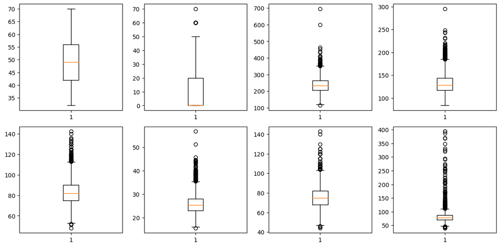

```python
# Checking for outliers

fig, axes = plt.subplots(2,4,figsize=(12,6))
n=1
for i in range(2):
    for j in range(4):
        axes[i,j].boxplot(df[Numeric_cols[n-1]])
        n+=1
plt.tight_layout()
plt.show()
```

### 2-6. Generating Plot(s)

```python
# generate plots to support your objective and goals
```

#### Question 1. To investigate

- A) How many smokers fall into each age group?
- B) What percentage of individuals within each age category are smokers?
- C) How does the average number of cigarettes smoked by individuals within each age group compare?

```python
df.head()
```

|  | Gender | age | currentSmoker | cigsPerDay | BPMeds | prevalentStroke | prevalentHyp | diabetes | totChol | sysBP | diaBP | BMI | heartRate | glucose | CHD Risk | age_category |
| --- | --- | --- | --- | --- | --- | --- | --- | --- | --- | --- | --- | --- | --- | --- | --- | --- |
| 0 | 1 | 39 | 0 | 0.0 | 0.0 | 0 | 0 | 0 | 195.0 | 106.0 | 70.0 | 26.97 | 80.0 | 77.0 | 0 | 32-45 |
| 1 | 0 | 46 | 0 | 0.0 | 0.0 | 0 | 0 | 0 | 250.0 | 121.0 | 81.0 | 28.73 | 95.0 | 76.0 | 0 | 45- 60 |
| 2 | 1 | 48 | 1 | 20.0 | 0.0 | 0 | 0 | 0 | 245.0 | 127.5 | 80.0 | 25.34 | 75.0 | 70.0 | 0 | 45- 60 |
| 3 | 0 | 61 | 1 | 30.0 | 0.0 | 0 | 1 | 0 | 225.0 | 150.0 | 95.0 | 28.58 | 65.0 | 103.0 | 1 | 60-70 |
| 4 | 0 | 46 | 1 | 23.0 | 0.0 | 0 | 0 | 0 | 285.0 | 130.0 | 84.0 | 23.10 | 85.0 | 85.0 | 0 | 45- 60 |

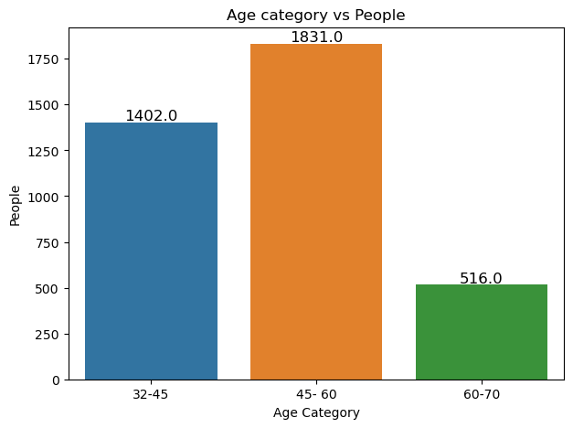

```python
#Age Groups and the total smokers in each age group
plt.figure(figsize=(7, 5))
ax=sns.countplot(x='age_category',data=df)
for p in ax.patches:
    ax.annotate(f'{p.get_height()}', (p.get_x() + p.get_width() / 2., p.get_height()), ha='center', va='center',
                fontsize=12, color='black', xytext=(0, 5), textcoords='offset points')

plt.title("Age category vs People")
plt.ylabel("People")
plt.xlabel("Age Category")
```

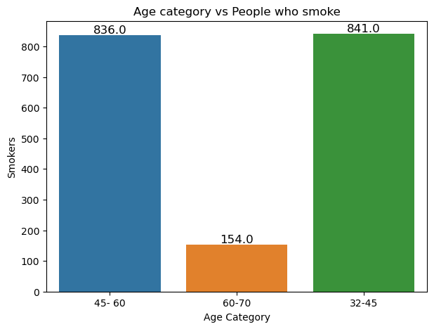

```python
plt.figure(figsize=(7, 5))
ax= sns.countplot(x='age_category',data=smokers_data)
for p in ax.patches:
    ax.annotate(f'{p.get_height()}', (p.get_x() + p.get_width() / 2., p.get_height()), ha='center', va='center',
                fontsize=12, color='black', xytext=(0, 5), textcoords='offset points')
plt.title("Age category vs People who smoke")
plt.ylabel("Smokers")
plt.xlabel("Age Category")
```

Based on the plot above, we can see that the largest proportion of smokers in the dataset belong to the age groups of 45 to 60 and 32 to 45, with a relatively less number of individuals who smoke in the 60-70 age range.

```python
#Now, let's find the percentage of individuals within each age category who are smokers
val=df.groupby('age_category')['currentSmoker'].mean().values
```

```python
cat=['32-45','45-60','60-70']
```

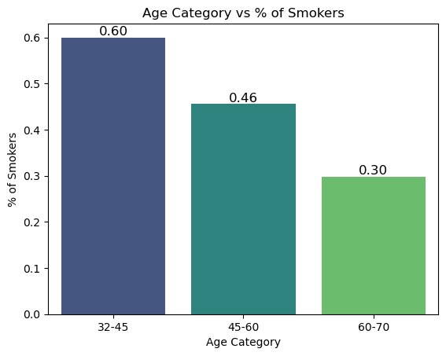

```python
ax =sns.barplot(x=cat,y=val,palette = 'viridis')
for p in ax.patches:
    ax.annotate(f'{p.get_height():.2f}', (p.get_x() + p.get_width() / 2., p.get_height()), ha='center', va='center',
                fontsize=12, color='black', xytext=(0, 5), textcoords='offset points')
plt.xlabel('Age Category')
plt.ylabel('% of Smokers')
plt.title('Age Category vs % of Smokers')
```

```python
# Comparison of Age Groups and the Average Number of Cigarettes Smoked by Individuals within Each Category
val=smokers_data.groupby('age_category')['cigsPerDay'].mean().values
```

```python
val
```

```
array([18.75148633, 18.51674641, 16.30519481])
```

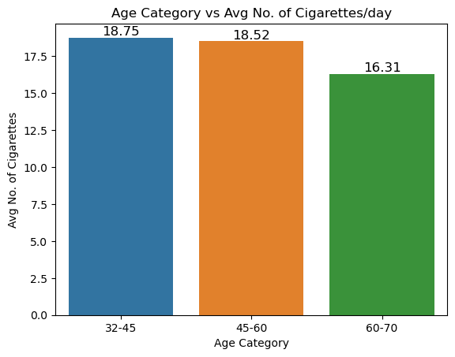

```python
ax=sns.barplot(x=cat,y=val)
for p in ax.patches:
    ax.annotate(f'{p.get_height():.2f}', (p.get_x() + p.get_width() / 2., p.get_height()), ha='center', va='center',
                fontsize=12, color='black', xytext=(0, 5), textcoords='offset points')

plt.xlabel('Age Category')
plt.ylabel('Avg No. of Cigarettes')
plt.title('Age Category vs Avg No. of Cigarettes/day')
```

#### Question 2:

Is there a relationship between the

- Number of Cigarettes and BMI
- Number of Cigarettes and heart rate
- Number of Cigarettes and diaBP
- Number of Cigarettes and CHD Risk
- Smokers with no risk and smokers with CHD risk.¶

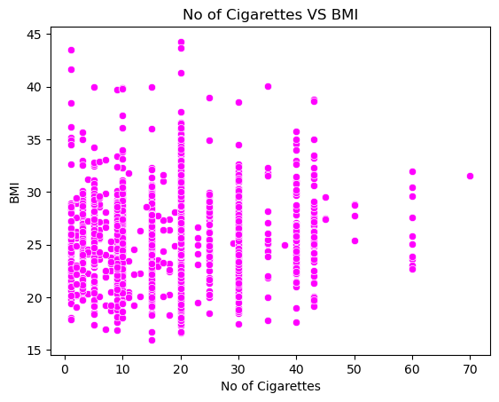

```python
# 2)I want to explore how the number of cigarettes affects BMI, heart rate, and the risk of coronary heart disease (CHD)

sns.scatterplot(x='cigsPerDay',y='BMI', data=smokers_data,color='magenta' )
plt.xlabel('No of Cigarettes')
plt.ylabel('BMI')
plt.title('No of Cigarettes VS BMI')
```

```python
correlation_matrix = np.corrcoef(smokers_data['cigsPerDay'],smokers_data['BMI'])
correlation_matrix
```

```
array([[1.        , 0.09032357],
       [0.09032357, 1.        ]])
```

From the correlation matrix we can see that as number of cigarettes smoked per day ('cigsPerDay') increases, there is a only slight tendency for the Body Mass Index ('BMI') to increase as well.

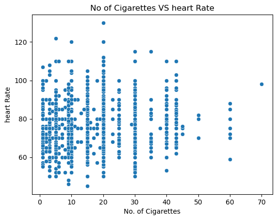

```python
sns.scatterplot(x='cigsPerDay',y='heartRate', data=smokers_data )
plt.xlabel('No. of Cigarettes')
plt.ylabel('heart Rate')
plt.title('No of Cigarettes VS heart Rate')
```

```python
correlation_matrix = np.corrcoef(smokers_data['cigsPerDay'],smokers_data['heartRate'])
correlation_matrix
```

```
array([[1.        , 0.05663569],
       [0.05663569, 1.        ]])
```

We can see as the number of cigarettes per day increases, there is a slight tendency for heart rate to also increase, but the relationship is not strong.

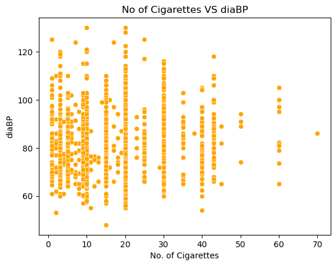

```python
sns.scatterplot(x='cigsPerDay',y='diaBP', data=smokers_data, color='orange')
plt.xlabel('No. of Cigarettes')
plt.ylabel('diaBP')
plt.title('No of Cigarettes VS diaBP')
```

```python
correlation_matrix = np.corrcoef(smokers_data['cigsPerDay'],smokers_data['diaBP'])
correlation_matrix
```

```
array([[1.        , 0.07333988],
       [0.07333988, 1.        ]])
```

Weak positive correlation between the number of cigarettes smoked per day and diastolic blood pressure (diabp)

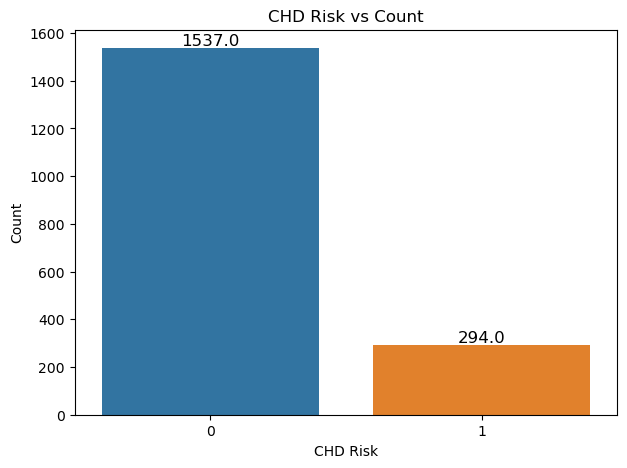

```python
plt.figure(figsize=(7, 5))
ax= sns.countplot(x='CHD Risk',data=smokers_data)
for p in ax.patches:
    ax.annotate(f'{p.get_height()}', (p.get_x() + p.get_width() / 2., p.get_height()), ha='center', va='center',
                fontsize=12, color='black', xytext=(0, 5), textcoords='offset points')
plt.title("CHD Risk vs Count")
plt.ylabel("Count")
plt.xlabel("CHD Risk")
```

##### Determining whether individuals with a high CHD risk or those with no risk smoke more cigarettes.

```python
zero_risk=list(smokers_data[smokers_data['CHD Risk']==0]['cigsPerDay'])
```

```python
risk=list(smokers_data[smokers_data['CHD Risk']==1]['cigsPerDay'])
```

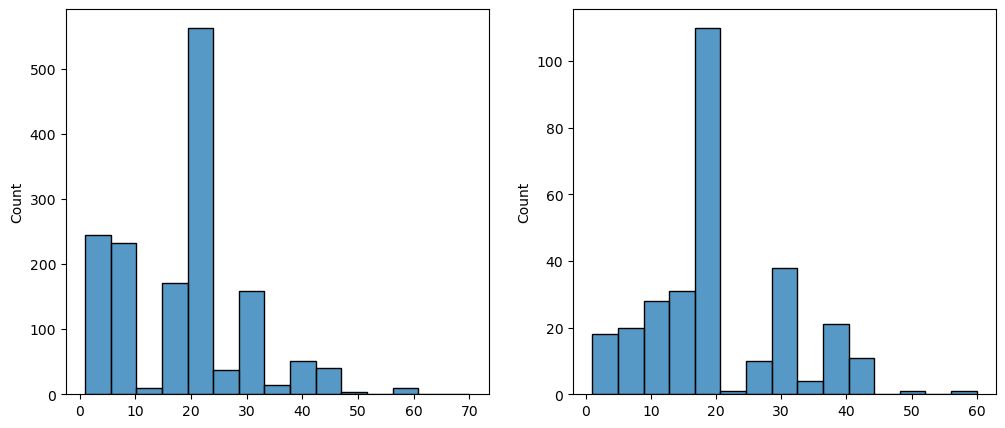

```python
plt.figure(figsize=(12, 5))
plt.subplot(121)
sns.histplot(zero_risk,bins=15)
plt.subplot(122)
sns.histplot(risk,bins=15)
```

#### Question 3:

- I want to determine whether smokers have a higher heart rate than non-smokers

```python
smokers=list(df[df['currentSmoker']==1]['heartRate'])
```

```python
non_smokers=list(df[df['currentSmoker']==0]['heartRate'])
```

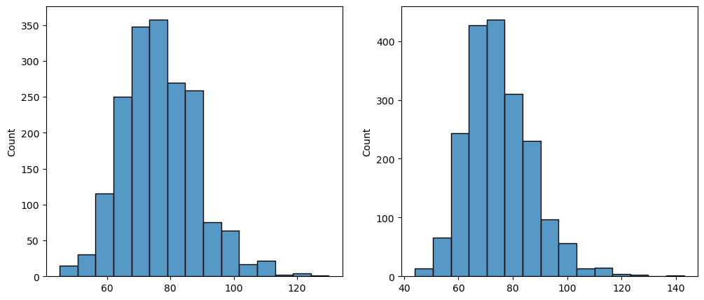

```python
plt.figure(figsize=(12, 5))
plt.subplot(121)
sns.histplot(smokers,bins=15)
plt.subplot(122)
sns.histplot(non_smokers,bins=15)
```

it appears that smokers have a slightly higher heart rate than non-smokers

```python
val=df.groupby('currentSmoker')['heartRate'].mean()
```

```python
val
```

```
currentSmoker
0    75.066736
1    76.371382
Name: heartRate, dtype: float64
```

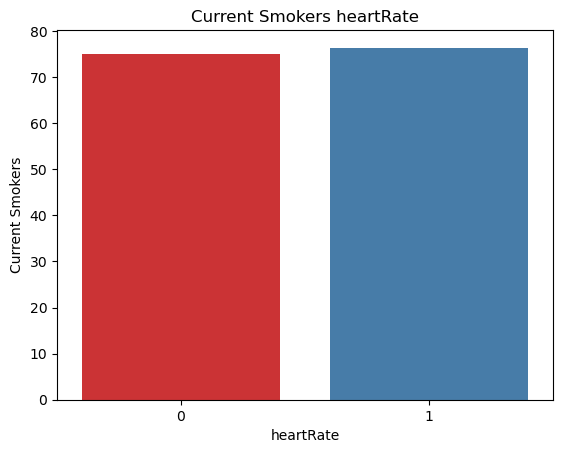

```python
sns.barplot(x=[0,1],y=val.values,palette='Set1')

plt.xlabel('heartRate')
plt.ylabel('Current Smokers')
plt.title('Current Smokers heartRate')
```

# 3. EDA

Heatmaps are useful for visualizing the relationships between two sets of categorical or numerical data

corr( ): calculates correlation coefficients between numerical columns in the DataFrame

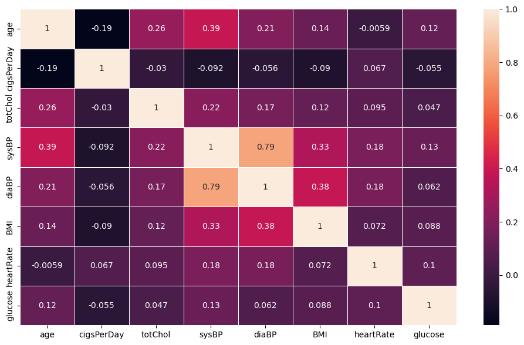

```python
corr_matrix=df[Numeric_cols].corr()
plt.figure(figsize=(12,7))
sns.heatmap(corr_matrix,annot=True,linewidths=0.5)
plt.show()
```

Exploration: From the heatmap above, we can see the following observations:

> 1. correlation coefficient of 0.79 between 'DiaBP' and 'sysBP' indicates a strong positive corelation, suggesting that as one increases, the other tends to increase.
> 2. 'CigsPerDay' and 'BMI' are negatively corelated.
> 3. 'CigsPerDay' and 'heartRate' suggests a weak positive relationship: as the number of cigarettes smoked per day increases, there is a slight tendency for the heart rate to also increase, but the correlation is not strong.

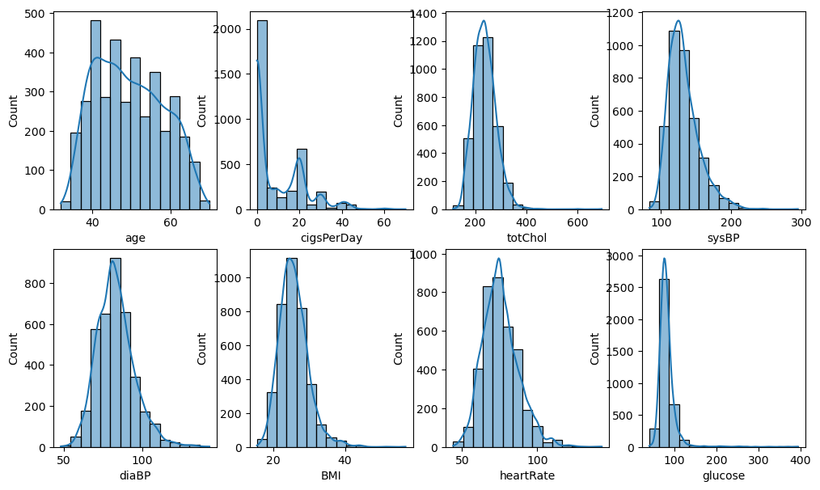

```python
# sns.histplot() shows how data values are distributed
Numeric_cols=['age', 'cigsPerDay', 'totChol', 'sysBP','diaBP', 'BMI', 'heartRate', 'glucose']
fig, axes = plt.subplots(2,4,figsize=(12,7))
n=1
for i in range(2):
    for j in range(4):
        sns.histplot(df[Numeric_cols[n-1]],ax=axes[i,j],bins=15,kde=True)
        axes[i,j].set_xlabel(Numeric_cols[n-1])
        n+=1

plt.show()
```

Exploration:  
In my exploration, I observed that several histograms (diabp,heartrate,sysBP,BMI) displayed a Gaussian distribution, indicating a bell-shaped curve centered around a mean value. This suggests that the data in those histograms may follow a normal distribution pattern, which can have important implications for statistical analysis and modeling.

Using the sns.countplot() to count number of male and female

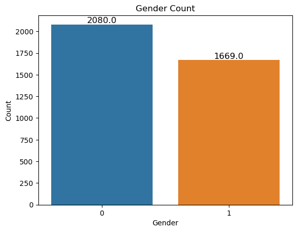

```python
ax=sns.countplot(x='Gender', data=df)
for p in ax.patches:
    ax.annotate(f'{p.get_height()}', (p.get_x() + p.get_width() / 2., p.get_height()), ha='center', va='center',
                fontsize=12, color='black', xytext=(0, 5), textcoords='offset points')
plt.xlabel("Gender")
plt.ylabel("Count")
plt.title("Gender Count")
plt.show()
```

Exploration:  
I use a countplot to visually represent and compare the number of males and females in my dataset, providing a clear overview of the gender distribution within the data.

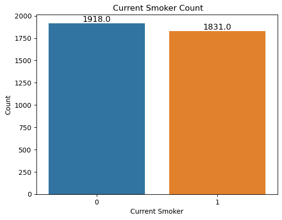

```python
#Counting how many people in the dataset are smokers.

ax=sns.countplot(x='currentSmoker', data=df)
for p in ax.patches:
    ax.annotate(f'{p.get_height()}', (p.get_x() + p.get_width() / 2., p.get_height()), ha='center', va='center',
                fontsize=12, color='black', xytext=(0, 5), textcoords='offset points')
plt.xlabel("Current Smoker")
plt.ylabel("Count")
plt.title(" Current Smoker Count")
plt.show()
```

Exploration:  
I used a countplot to examine the number of smokers in the dataset, as smoking is a potential major factor contributing to Coronary Heart Disease (CHD).

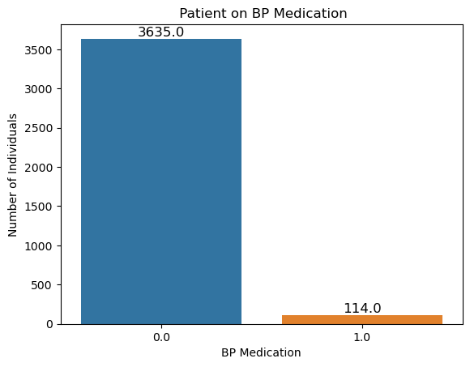

```python
# Counting how many Patient in the dataset taking BP Medication

ax=sns.countplot(x='BPMeds', data=df)
for p in ax.patches:
    ax.annotate(f'{p.get_height()}', (p.get_x() + p.get_width() / 2., p.get_height()), ha='center', va='center',
                fontsize=12, color='black', xytext=(0, 5), textcoords='offset points')
plt.xlabel("BP Medication")
plt.ylabel("Number of Individuals")
plt.title(" Patient on BP Medication")
plt.show()
```

Exploration:  
I visualized the number of patients in the dataset who are taking BP medication. we can observe from the plot that only 114 people taking BP Medication out of 3749.

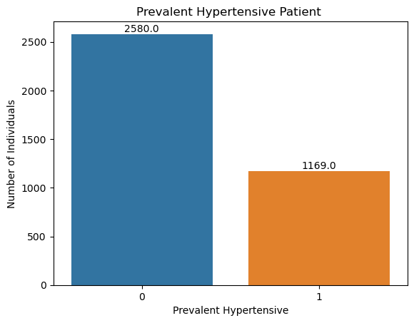

```python
# Counting how many Patient in the dataset are hypertensive

ax=sns.countplot(x='prevalentHyp', data=df)
for p in ax.patches:
    ax.annotate(f'{p.get_height()}', (p.get_x() + p.get_width() / 2., p.get_height()), va='center',
                fontsize=10,  ha='center', color='black',textcoords='offset points', xytext=(0, 5))
plt.xlabel("Prevalent Hypertensive")
plt.ylabel("Number of Individuals")
plt.title("Prevalent Hypertensive Patient ")
plt.show()
```

Exploration:  
I counted the number of hypertensive patients in the dataset, finding that 1,169 individuals have hypertension, while 2,580 do not. This information provides valuable insight into the relationship between hypertension and coronary heart disease (CHD)

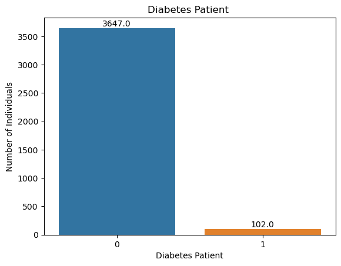

```python
# Counting number of diabetes patient

ax=sns.countplot(x='diabetes', data=df)
sns.set_palette("colorblind")
for p in ax.patches:
    ax.annotate(f'{p.get_height()}', (p.get_x() + p.get_width() / 2., p.get_height()), va='center',
                fontsize=10,  ha='center', color='black',textcoords='offset points', xytext=(0, 5))
plt.xlabel("Diabetes Patient")
plt.ylabel("Number of Individuals")
plt.title("Diabetes Patient ")
plt.show()
```

sns.scatterplot(): Shows the relationship between two features  
hue: It represents a categorical variable that colors data points differently based on their category, helping to visualize additional information.

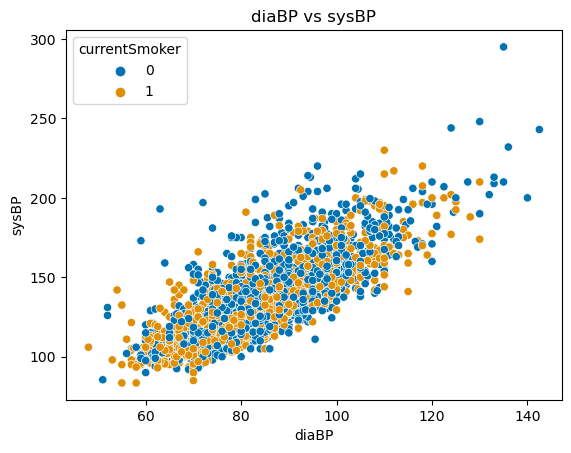

```python
sns.scatterplot(x = 'diaBP', y = 'sysBP', data = df, color='Purple',hue='currentSmoker')
plt.title("diaBP vs sysBP")
plt.show()
```

Exploration:  
In my exploration, I plotted a scatterplot between systolic blood pressure (sysBP) and diastolic blood pressure (Diabp) for my dataset and observed a clear increasing trend, indicating a positive correlation between these two variables.

# 4. Conclusion

#### Q3. Determine whether individuals who smoke exhibit higher heart rates compared to those who do not smoke.

> Here I plot the histogram to check who exhibit higher heart rate(Smokers or Non-smokers). The results indicate that Smokers have a slightly higher heart rate than non-smokers

# 5. Summary

The findings highlight the importance of age groups in understanding smoking patterns and suggest potential correlations between smoking and health variables.

#### FUTURE WORK

As for future work, it would be valuable to explore these relationships and train the databset with a larger and more diverse dataset, potentially incorporating additional variables and considering the impact of smoking on health factors and CHD. Additionally, advanced statistical modeling and machine learning techniques could be applied to gain deeper insights into the impact of smoking on cardiovascular health.

# References

> Dr. Yoonsung Jung's notes for the STAT 650 course: https://canvas.tamu.edu/  
> Pandas docs: https://pandas.pydata.org/docs/  
> Seaborn docs https://seaborn.pydata.org/  
> Matplotlib docs: https://matplotlib.org/  
> Kaggle website: https://www.kaggle.com/datasets/dileep070/heart-disease-prediction-using-logistic-regression?select=framingham.csv